# auto_correlation

### Regression Analysis of correlated data using OLS.

#### We know that OLS gives the best linear unbiased estimators when all the [Gauss Markov Assumptions](https://en.wikipedia.org/wiki/Gauss%E2%80%93Markov_theorem) are met. One such assumption is random sampling. Let us see how the estimators behave when this assumption is violated.

One of the way to violate this error is creating serial dependencies on dependent and independent variables.

Let us begin by generating dependent and independent variables using the following data generating processes.

$$x_t = x_{t-1,i} + u_{t,i} , u_{t,i} \sim iid \mathcal{N} (0, \sigma^2) $$

for $t = 1,2,....T $ and $i = 1,2,.....n$.

Let's use a similar process to generate another feature, say {$y_{t}$} $$y_t = y_{t-1} + e_t , e_t \sim iid \mathcal{N} (0, \sigma^2) $$ for $t = 1,2,....T$

```python
#importing the necessary packages
import numpy as np
import pandas as pd
import random
from statsmodels import api as sm
import matplotlib.pyplot as plt
import scipy as sc
```

#### Let's generate $x_{t,i}$ for $t = 1$ and $i = 1$, $x_1 = x_{0} + u_{1i} , u_{1i} \sim iid \mathcal{N} (0, \sigma^2) $ and

$y_{t}$ for $t = 1$, $y_1 = y_{0} + e_{1} , e_{1} \sim iid \mathcal{N} (0, \sigma^2) $

```python
t=1
e=[]
y=[]
u=[]
x=[]
#initial y gen
y.append(random.normalvariate(4,1))
#initial x gen
x.append(random.normalvariate(10,1))
#generate errors
simn = 1000
random.seed(2)
for isim in range(0,simn):
    #error e gen
    e.append(random.normalvariate(0,1))
    #error u gen
    u.append(random.normalvariate(0,1))
for isim in range(1,simn):
    #generate y
    y.append(y[isim-t]+e[isim])
    #generate x
    x.append(x[isim-t]+u[isim])
x=np.array(x).reshape(-1,1)
y=np.array(y)
ones = np.ones((len(x),1))
x = np.hstack((ones,x))
```

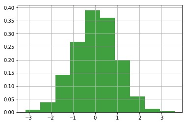

```python
# the histogram of the error
n, bins, patches = plt.hist(e, 10, density=True, facecolor='g', alpha=0.75)
plt.grid(True)
plt.show()
```

#### Here, we can see that the error is normally distributed about zero.

#### Let's analyze y

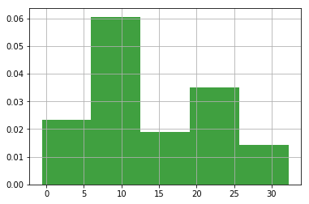

```python
# the histogram of the y
n, bins, patches = plt.hist(y, 5, density=True, facecolor='g', alpha=0.75)
plt.grid(True)
plt.show()
```

#### We can see that y is not normally distributed.

#### Similarly, let's see the histograms of u and x.

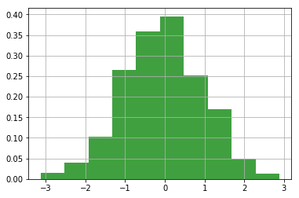

```python
# the histogram of the u
n, bins, patches = plt.hist(u, 10, density=True, facecolor='g', alpha=0.75)
plt.grid(True)
plt.show()
```

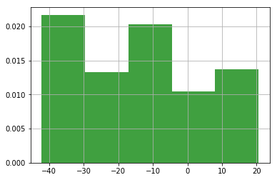

```python
# the histogram of the x
n, bins, patches = plt.hist(x[:,1], 5, density=True, facecolor='g', alpha=0.75)
plt.grid(True)
plt.show()
```

#### Let's build the following model using OLS

#### $y_t = \beta_0 + \beta_1 x_t + \epsilon_t$

```python
# regression of x on y
model1 = sm.OLS(y,x).fit()
print(model1.summary())
```

```
                            OLS Regression Results
==============================================================================
Dep. Variable:                      y   R-squared:                       0.732
Model:                            OLS   Adj. R-squared:                  0.732
Method:                 Least Squares   F-statistic:                     2730.
Date:                Tue, 21 May 2019   Prob (F-statistic):          7.47e-288
Time:                        17:03:52   Log-Likelihood:                -2860.2
No. Observations:                1000   AIC:                             5724.
Df Residuals:                     998   BIC:                             5734.
Df Model:                           1
Covariance Type:            nonrobust
==============================================================================
                 coef    std err          t      P>|t|      [0.025      0.975]
------------------------------------------------------------------------------
const          8.7965      0.167     52.775      0.000       8.469       9.124
x1            -0.3762      0.007    -52.249      0.000      -0.390      -0.362
==============================================================================
Omnibus:                        6.544   Durbin-Watson:                   0.061
Prob(Omnibus):                  0.038   Jarque-Bera (JB):                5.690
Skew:                          -0.118   Prob(JB):                       0.0581
Kurtosis:                       2.715   Cond. No.                         28.9
==============================================================================

Warnings:
[1] Standard Errors assume that the covariance matrix of the errors is correctly specified.
```

#### We can see that the [Durbin-Watson](https://www.investopedia.com/terms/d/durbin-watson-statistic.asp) score is 0.061 which suggests that there is positive auto correlation

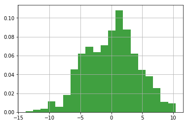

```python
# the histogram of the data
residuals=np.array(model1.resid).reshape(-1,1)
n, bins, patches = plt.hist(residuals, 20, density=True, facecolor='g', alpha=0.75)
#plt.axis([-1, 1, 0, 20])
plt.grid(True)
plt.show()
```

Lets look into the correlation of error terms.

```python
model1 = sm.OLS(y,x).fit(cov_type='HC0')
print(model1.summary())
```

```
                            OLS Regression Results
==============================================================================
Dep. Variable:                      y   R-squared:                       0.732
Model:                            OLS   Adj. R-squared:                  0.732
Method:                 Least Squares   F-statistic:                     3141.
Date:                Tue, 21 May 2019   Prob (F-statistic):          1.58e-310
Time:                        17:03:56   Log-Likelihood:                -2860.2
No. Observations:                1000   AIC:                             5724.
Df Residuals:                     998   BIC:                             5734.
Df Model:                           1
Covariance Type:                  HC0
==============================================================================
                 coef    std err          z      P>|z|      [0.025      0.975]
------------------------------------------------------------------------------
const          8.7965      0.153     57.330      0.000       8.496       9.097
x1            -0.3762      0.007    -56.045      0.000      -0.389      -0.363
==============================================================================
Omnibus:                        6.544   Durbin-Watson:                   0.061
Prob(Omnibus):                  0.038   Jarque-Bera (JB):                5.690
Skew:                          -0.118   Prob(JB):                       0.0581
Kurtosis:                       2.715   Cond. No.                         28.9
==============================================================================

Warnings:
[1] Standard Errors are heteroscedasticity robust (HC0)
```

#### Let's plot residual plots to get a better understanding of the error distribution.

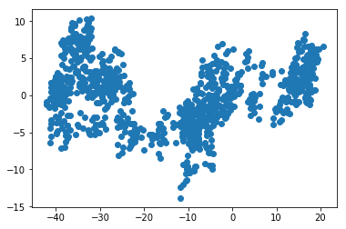

```python
plt.scatter(x[:,1],residuals.flatten())
```

#### We can see that there is heterogenity in error terms. This leads to bias in our estimators and therefore, the OLS estimators are no longer BLUE (best linear unbiased estimators).

```python
sc.stats.levene(y,x[:,1])
```

```
LeveneResult(statistic=663.1214037868205, pvalue=1.6141243531100978e-126)
```

```python
sc.stats.ttest_ind(y,x[:,1])
```

```
Ttest_indResult(statistic=43.294390393344614, pvalue=2.0469050973291668e-289)
```

#### Let's analyze the case for Multivariate Linear Regressions

```python
t=1
e=[]
y=[]
u=[]
x=[]
#initial y gen
n = 2
y.append(random.normalvariate(4,1))
#initial x gen
x.append(np.random.normal(10,1,n))
#generate errors
simn = 1000
random.seed(2)
for isim in range(0,simn):
    #error e gen
    e.append(random.normalvariate(0,1))
    #error u gen
    u.append(np.random.normal(0,1,n))
for isim in range(1,simn):
    #generate y
    y.append(y[isim-t]+e[isim])
    #generate x
    x.append(x[isim-t]+u[isim])
x=np.array(x).reshape(-1,n)
y=np.array(y)
ones = np.ones((len(x),1))
x = np.hstack((ones,x))
```

```python
x.shape
```

```
(1000, 3)
```

```python
# regression of x on y
model1 = sm.OLS(y,x).fit()
print(model1.summary())
```

```
                            OLS Regression Results
==============================================================================
Dep. Variable:                      y   R-squared:                       0.612
Model:                            OLS   Adj. R-squared:                  0.612
Method:                 Least Squares   F-statistic:                     787.7
Date:                Tue, 21 May 2019   Prob (F-statistic):          6.15e-206
Time:                        20:45:46   Log-Likelihood:                -3221.0
No. Observations:                1000   AIC:                             6448.
Df Residuals:                     997   BIC:                             6463.
Df Model:                           2
Covariance Type:            nonrobust
==============================================================================
                 coef    std err          t      P>|t|      [0.025      0.975]
------------------------------------------------------------------------------
const         12.0352      0.426     28.281      0.000      11.200      12.870
x1            -0.2656      0.031     -8.548      0.000      -0.327      -0.205
x2            -0.7065      0.022    -31.722      0.000      -0.750      -0.663
==============================================================================
Omnibus:                       14.657   Durbin-Watson:                   0.040
Prob(Omnibus):                  0.001   Jarque-Bera (JB):               13.561
Skew:                           0.239   Prob(JB):                      0.00114
Kurtosis:                       2.689   Cond. No.                         41.4
==============================================================================

Warnings:
[1] Standard Errors assume that the covariance matrix of the errors is correctly specified.
```

```python
model1 = sm.OLS(y,x).fit(cov_type='HC0')
print(model1.summary())
```

```
                            OLS Regression Results
==============================================================================
Dep. Variable:                      y   R-squared:                       0.612
Model:                            OLS   Adj. R-squared:                  0.612
Method:                 Least Squares   F-statistic:                     828.4
Date:                Tue, 21 May 2019   Prob (F-statistic):          1.11e-212
Time:                        20:48:45   Log-Likelihood:                -3221.0
No. Observations:                1000   AIC:                             6448.
Df Residuals:                     997   BIC:                             6463.
Df Model:                           2
Covariance Type:                  HC0
==============================================================================
                 coef    std err          z      P>|z|      [0.025      0.975]
------------------------------------------------------------------------------
const         12.0352      0.329     36.594      0.000      11.391      12.680
x1            -0.2656      0.033     -7.939      0.000      -0.331      -0.200
x2            -0.7065      0.019    -36.516      0.000      -0.744      -0.669
==============================================================================
Omnibus:                       14.657   Durbin-Watson:                   0.040
Prob(Omnibus):                  0.001   Jarque-Bera (JB):               13.561
Skew:                           0.239   Prob(JB):                      0.00114
Kurtosis:                       2.689   Cond. No.                         41.4
==============================================================================

Warnings:
[1] Standard Errors are heteroscedasticity robust (HC0)
```

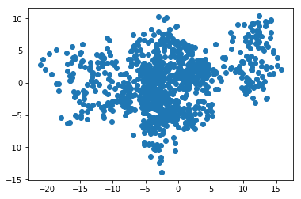

```python
plt.scatter(x[:,1],residuals.flatten())
```

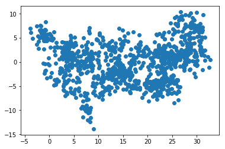

```python
plt.scatter(x[:,2],residuals.flatten())
```

```python
sc.stats.levene(y,x[:,1],x[:,2])
```

```
LeveneResult(statistic=160.18648446129512, pvalue=8.031994802470273e-67)
```

```python
[sc.stats.ttest_ind(y,x[:,1]),sc.stats.ttest_ind(y,x[:,2])]
```

```
[Ttest_indResult(statistic=6.957613621196703, pvalue=4.673644578948617e-12),
 Ttest_indResult(statistic=-34.82903392988044, pvalue=4.1258493384478805e-208)]
```

Now let's analyze how the number of samples effect the overall R-square

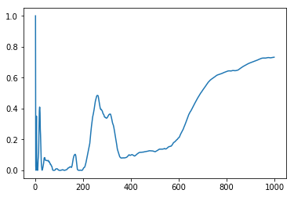

```python
t=1
e=[]
y=[]
u=[]
x=[]
#initial y gen
y.append(random.normalvariate(4,1))
#initial x gen
x.append(random.normalvariate(10,1))
#generate errors
simn = 1000
random.seed(2)
R_sq = [0]
for isim in range(0,simn):
    #error e gen
    e.append(random.normalvariate(0,1))
    #error u gen
    u.append(random.normalvariate(0,1))
for isim in range(1,simn):
    #generate y
    y.append(y[isim-t]+e[isim])
    #generate x
    x.append(x[isim-t]+u[isim])
    x_ar = np.array(x).reshape(-1,1)
    ones = np.ones((len(x),1))
    x_ar = np.hstack((ones,x_ar))
    y_ar=np.array(y)
    model1 = sm.OLS(y_ar,x_ar).fit()
    R_sq.append(model1.rsquared)
plt.plot(range(1,simn),R_sq[1:])
```

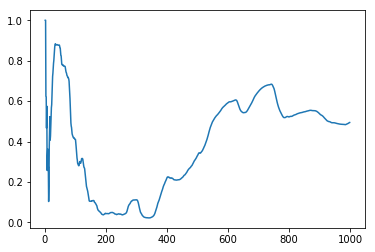

```python
t=1
e=[]
y=[]
u=[]
x=[]
#initial y gen
n = 2
y.append(random.normalvariate(4,1))
#initial x gen
x.append(np.random.normal(10,1,n))
#generate errors
simn = 1000
random.seed(2)
R_sq =[0]
for isim in range(0,simn):
    #error e gen
    e.append(random.normalvariate(0,1))
    #error u gen
    u.append(np.random.normal(0,1,n))
for isim in range(1,simn):
    #generate y
    y.append(y[isim-t]+e[isim])
    #generate x
    x.append(x[isim-t]+u[isim])
    x_ar = np.array(x).reshape(-1,n)
    ones = np.ones((len(x),1))
    x_ar = np.hstack((ones,x_ar))
    y_ar=np.array(y)
    model1 = sm.OLS(y_ar,x_ar).fit()
    R_sq.append(model1.rsquared)
plt.plot(range(1,simn),R_sq[1:])
```

```python
np.shape(R_sq)
```

```
(1000,)
```

```
time lags -  1
```

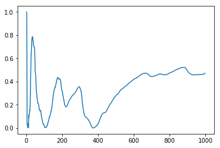

```
time lags -  5
```

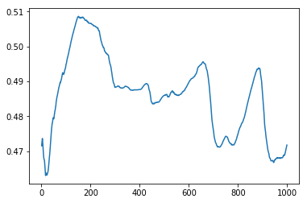

```
time lags -  10
```

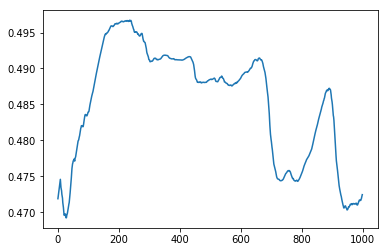

```
time lags -  15
```

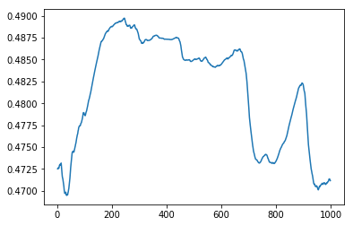

```
time lags -  20
```

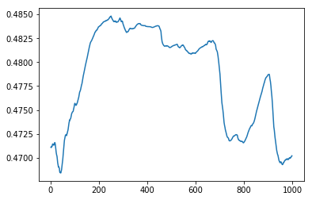

```
time lags -  25
```

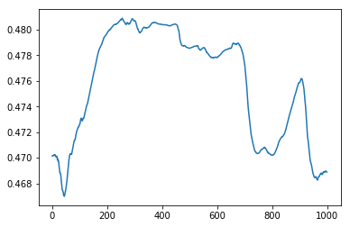

```
time lags -  30
```

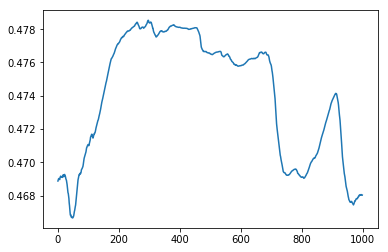

```
time lags -  35
```

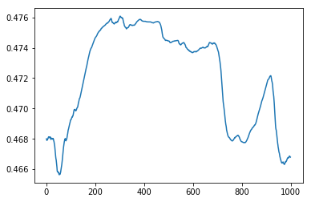

```
time lags -  40
```

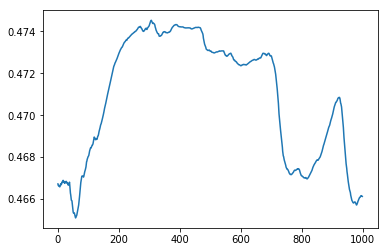

```
time lags -  45
```

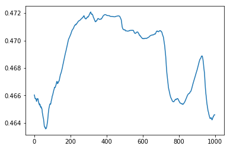

```
time lags -  50
```

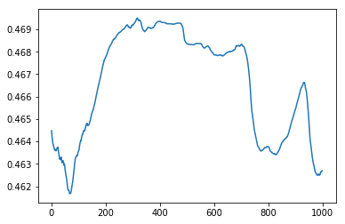

```python
e=[]
y=[]
u=[]
x=[]
#initial y gen
n = 1
y.append(random.normalvariate(4,1))
#initial x gen
x.append(np.random.normal(10,1,n))
#generate errors
simn = 1000
outp = []
time = []
R_sq = []
random.seed(2)
T = [1,5,10,15,20,25,30,35,40,45,50]
for t in T:
    for isim in range(0,simn):
        #error e gen
        e.append(random.normalvariate(0,1))
        #error u gen
        u.append(np.random.normal(0,1,n))
    for isim in range(1,simn):
        #generate y
        y.append(y[isim-t]+e[isim])
        #generate x
        x.append(x[isim-t]+u[isim])
        x_ar = np.array(x).reshape(-1,n)
        ones = np.ones((len(x),1))
        x_ar = np.hstack((ones,x_ar))
        y_ar=np.array(y)
        model1 = sm.OLS(y_ar,x_ar).fit()
        outp.append(model1.rsquared)
        #time.append(t)
    print("time lags - ",t)
    R_sq.append(model1.rsquared)
    plt.plot(range(1,simn),outp)
    plt.show()
    outp=[]
```

```python
R_sq
```

```
[0.47088425245019117,
 0.4717724413196147,
 0.4724619654390314,
 0.4711664537473812,
 0.4701963073995665,
 0.4688805089953919,
 0.46803248123375674,
 0.4667960421727889,
 0.4661261992201583,
 0.46458610304692816,
 0.4626924966085799]
```